# R Notebook

#### PrecipTotal vs WnvPresent

```r
# Overall
getStats(trainDataFE, var = PrecipTotal)
```

|  | Value |
| --- | --- |
| count | 8474.0000000 |
| na | 0.0000000 |
| min | 0.0000000 |
| max | 3.9700000 |
| mean | 0.1421961 |
| median | 0.0000000 |
| range | 3.9700000 |
| sd | 0.3554700 |
| variance | 0.1263589 |
| skewness | 5.2257378 |

[output cut: 1 more lines]

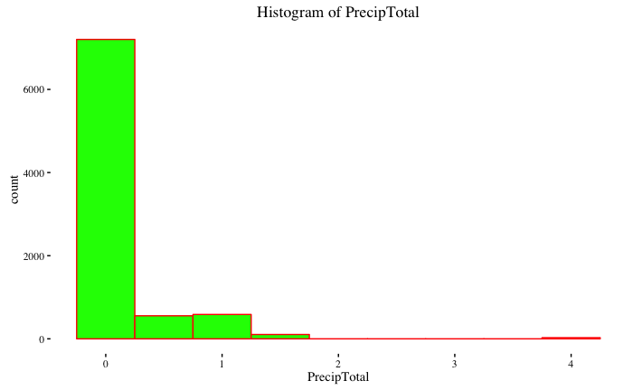

```r
plotHist(data = trainDataFE, bin_width = 0.5,  x = PrecipTotal)
```

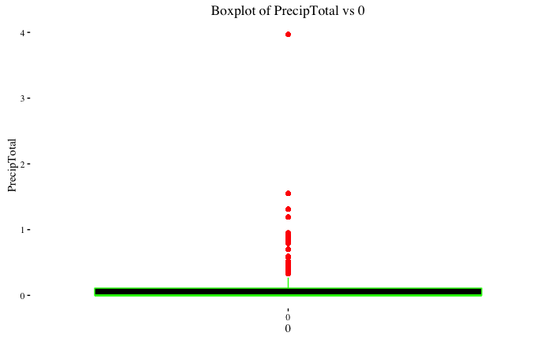

```r
plotBox(data = trainDataFE, x = 0, y = PrecipTotal)
```

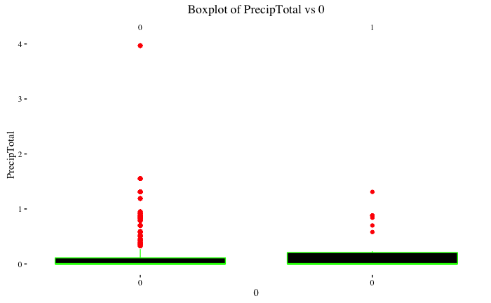

```r
plotBox(data = trainDataFE, x = 0, y = PrecipTotal)  + facet_wrap( ~ WnvPresent)
```

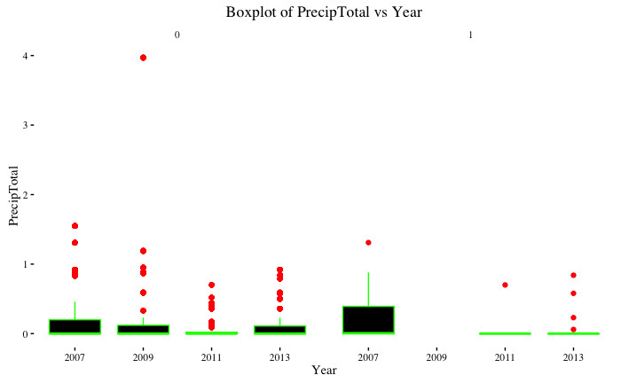

```r
# Year
plotBox(data = trainDataFE, x = Year, y = PrecipTotal) +
    facet_wrap(~ WnvPresent)
```

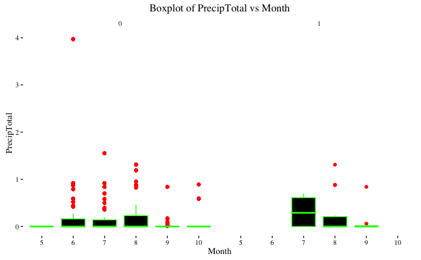

```r
# Month
plotBox(data = trainDataFE, x = Month, y = PrecipTotal) +
    facet_wrap(~ WnvPresent)
```

[figure not shown]

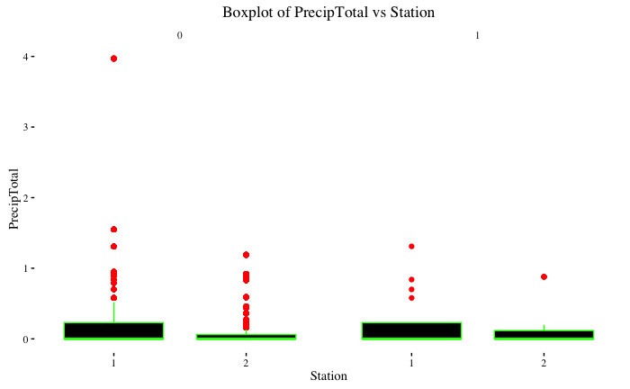

```r
# Station
plotBox(data = trainDataFE, x = Station, y = PrecipTotal) +
    facet_wrap(~ WnvPresent)
```

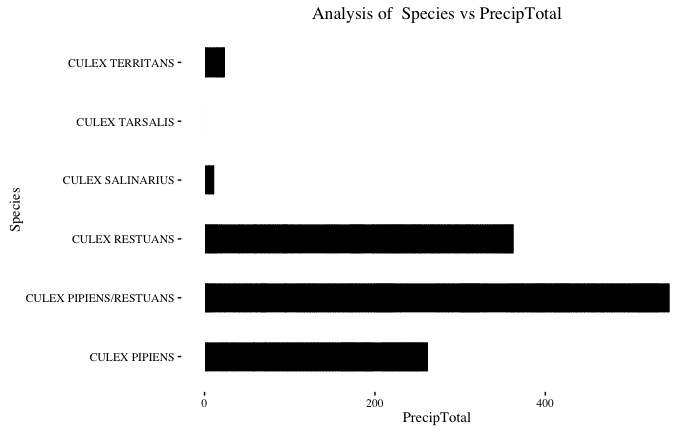

```r
# Species
# overall
plotBar(data = trainDataFE, x = Species, y = PrecipTotal) + coord_flip()
```

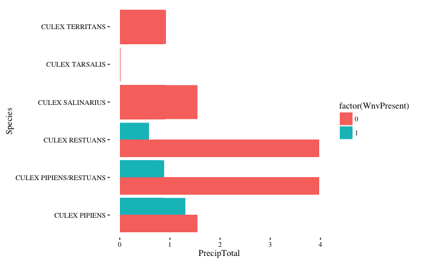

```r
# distribution by target
ggplot(data = trainDataFE, aes(Species, PrecipTotal)) +
    geom_bar(aes(fill = factor(WnvPresent)),
                 stat = "identity", position = "dodge") + coord_flip() + theme_tufte()
```

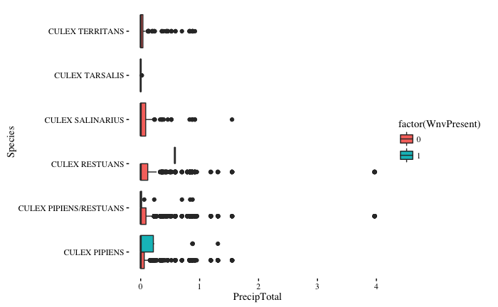

```r
# variability
ggplot(data = trainDataFE, aes(Species, PrecipTotal))  +
    geom_boxplot(aes(fill = factor(WnvPresent))) + coord_flip() + theme_tufte()
```

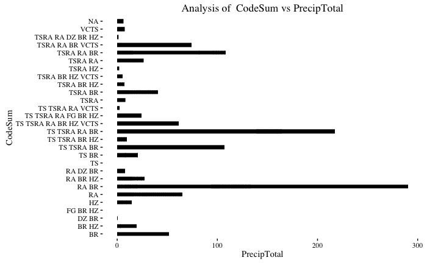

```r
# Code Sum
plotBar(data = trainDataFE, x = CodeSum, y = PrecipTotal) + coord_flip()
```

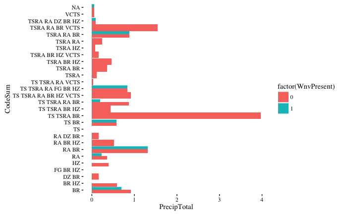

```r
# distribution by target
ggplot(data = trainDataFE, aes(CodeSum, PrecipTotal)) +
    geom_bar(aes(fill = factor(WnvPresent)),
                 stat = "identity", position = "dodge") + coord_flip() + theme_tufte()
```

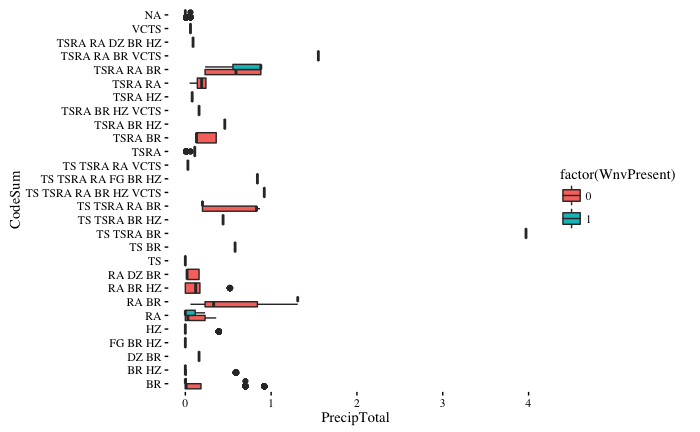

```r
# variability
ggplot(data = trainDataFE, aes(CodeSum, PrecipTotal))  +
    geom_boxplot(aes(fill = factor(WnvPresent))) + coord_flip() + theme_tufte()
```

#### Avg wind speed vs WnvPresent

- Observations:
  - Avg wind speed seems to have an impact.
  - Lower it is, greater the variability found when WNV = 1 vs WNV = 0

```r
# Overall
getStats(trainDataFE, var = AvgSpeed)
```

|  | Value |
| --- | --- |
| count | 8474.0000000 |
| na | 0.0000000 |
| min | 2.1000000 |
| max | 16.3000000 |
| mean | 7.5192353 |
| median | 7.2000000 |
| range | 14.2000000 |
| sd | 2.5039396 |
| variance | 6.2697138 |
| skewness | 0.5372375 |

[output cut: 1 more lines]

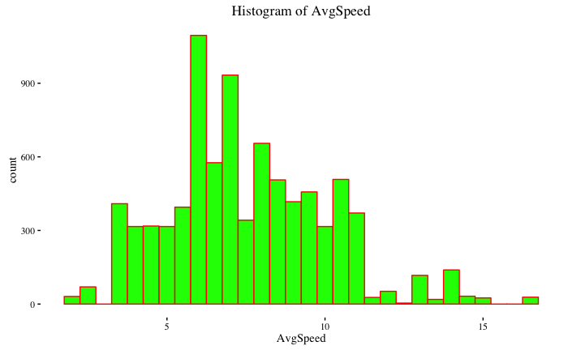

```r
plotHist(data = trainDataFE, bin_width = 0.5,  x = AvgSpeed)
```

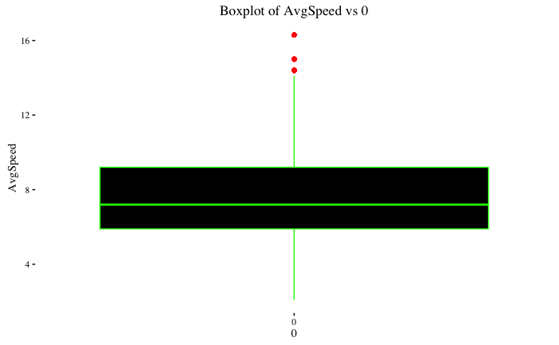

```r
plotBox(data = trainDataFE, x = 0, y = AvgSpeed)
```

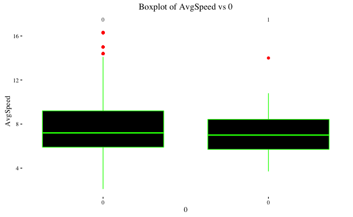

```r
plotBox(data = trainDataFE, x = 0, y = AvgSpeed)  + facet_wrap( ~ WnvPresent)
```

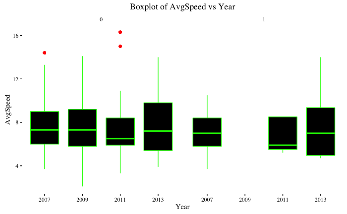

```r
# Year
plotBox(data = trainDataFE, x = Year, y = AvgSpeed) +
    facet_wrap(~ WnvPresent)
```

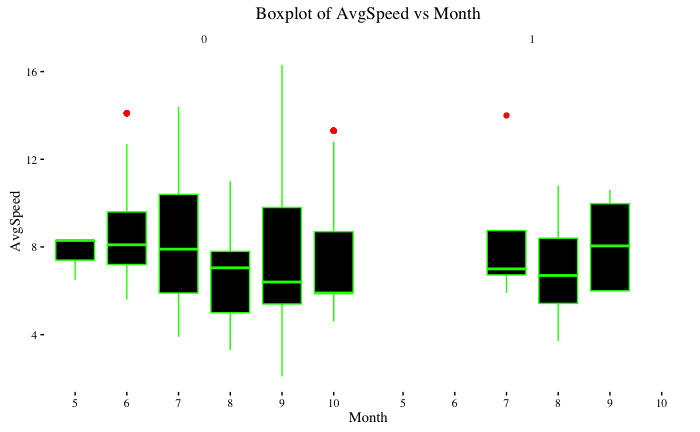

```r
# Month
plotBox(data = trainDataFE, x = Month, y = AvgSpeed) +
    facet_wrap(~ WnvPresent)
```

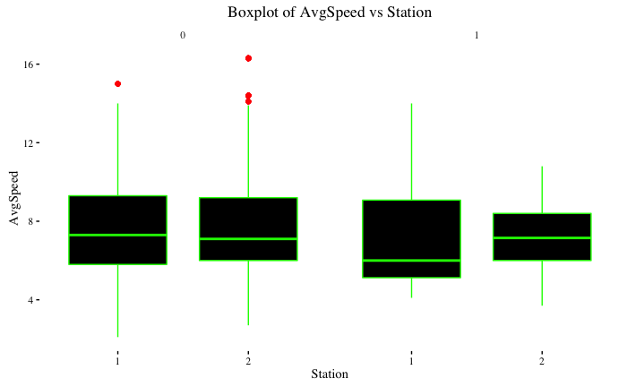

```r
# Station
plotBox(data = trainDataFE, x = Station, y = AvgSpeed) +
    facet_wrap(~ WnvPresent)
```

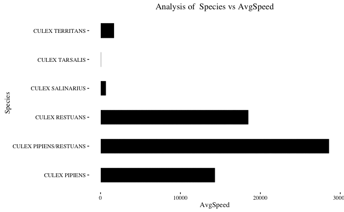

```r
# Species
# overall
plotBar(data = trainDataFE, x = Species, y = AvgSpeed) + coord_flip()
```

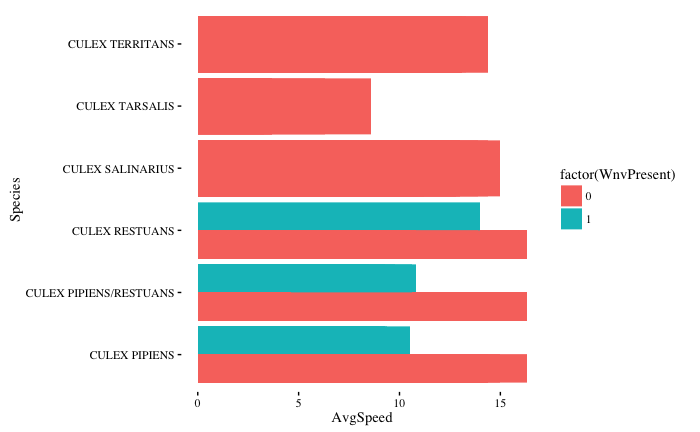

```r
# distribution by target
ggplot(data = trainDataFE, aes(Species, AvgSpeed)) +
    geom_bar(aes(fill = factor(WnvPresent)),
                 stat = "identity", position = "dodge") + coord_flip() + theme_tufte()
```

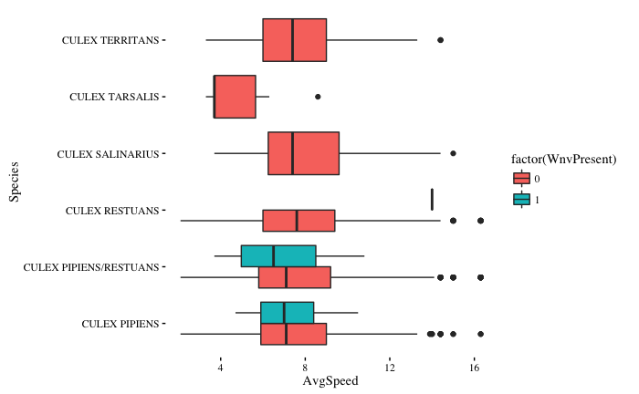

```r
# variability
ggplot(data = trainDataFE, aes(Species, AvgSpeed))  +
    geom_boxplot(aes(fill = factor(WnvPresent))) + coord_flip() + theme_tufte()
```

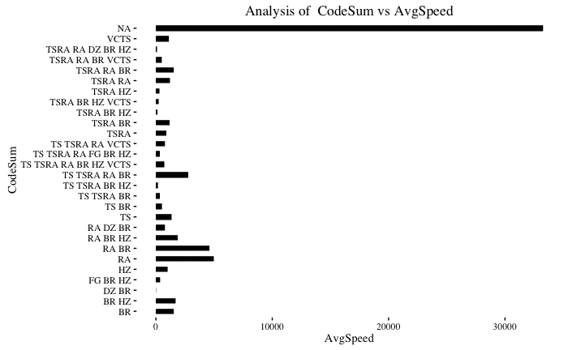

```r
# Code Sum
plotBar(data = trainDataFE, x = CodeSum, y = AvgSpeed) + coord_flip()
```

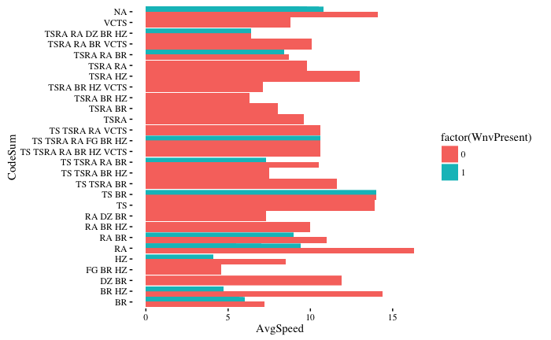

```r
# distribution by target
ggplot(data = trainDataFE, aes(CodeSum, AvgSpeed)) +
    geom_bar(aes(fill = factor(WnvPresent)),
                 stat = "identity", position = "dodge") + coord_flip() + theme_tufte()
```

[figure not shown]

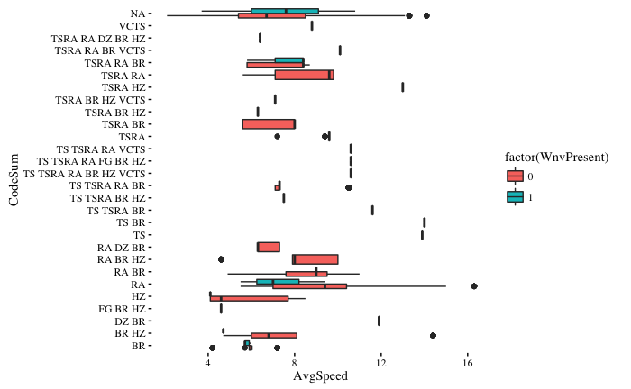

```r
# variability
ggplot(data = trainDataFE, aes(CodeSum, AvgSpeed))  +
    geom_boxplot(aes(fill = factor(WnvPresent))) + coord_flip() + theme_tufte()
```

## Predictive Modeling

- Methodology:
  - Following featutes are controllable or known:
    - Latitude, Longitude i.e. location info.
    - Time information
    - Weather information
    - No of mosquitos found
  - Based on these we will need to predict if WNV virus is found or not
  - No.of Mosquitos is not provided in the test data, so we will have to predict it.
  - Assumption is that if we can predict the number of mosquitos then we can confidently predict whether WNV is found in them or not.
- We will use the following strategy:
  - Create a multi-variate regression model to Predict # of mosquitos.
  - Use that to predict NumMosquitos in test data.
  - Use boosted decision trees to predict WnvPresent

### Predicting Num of Mosquitos

```r
set.seed(123) # set the seed so that the result is reproducible
# Multivariate Linear Model
# Creation of Linear Model
formula.lm <-
    NumMosquitos ~ Month + Day + Week + Latitude + Longitude + Station + Tavg +
    Tmax + Tmin + Heat + Cool + AvgSpeed + ResultSpeed + PrecipTotal + Station +
    Species + DewPoint + ResultDir + CodeLen
# Fitting Linear Model
fit.lm <- lm(formula = formula.lm, data = trainDataFE)
summary(fit.lm) # get the output of the model
```

```
Call:
lm(formula = formula.lm, data = trainDataFE)

Residuals:
    Min      1Q  Median      3Q     Max
 -45.14  -17.09   -8.41    1.96 2494.89

Coefficients: (1 not defined because of singularities)
                                Estimate Std. Error t value Pr(>|t|)
(Intercept)                   2268.22833 1119.57098   2.026   0.0428 *
Month                           -0.59223   14.64540  -0.040   0.9677
Day                              0.02590    0.47968   0.054   0.9569
Week                            -0.31787    3.30892  -0.096   0.9235
Latitude                      -120.32349   12.10921  -9.937  < 2e-16 ***
Longitude                      -31.54111   13.18974  -2.391   0.0168 *
Station                        -21.32240    2.88999  -7.378 1.76e-13 ***
Tavg                             2.53192    3.32280   0.762   0.4461
Tmax                            -1.03083    1.68834  -0.611   0.5415
Tmin                            -0.66166    1.70262  -0.389   0.6976
Heat                             0.64933    0.47925   1.355   0.1755
Cool                                  NA         NA      NA       NA
AvgSpeed                         0.42602    0.85923   0.496   0.6200
ResultSpeed                     -0.37145    0.70479  -0.527   0.5982
PrecipTotal                     -4.81518    2.77469  -1.735   0.0827 .
SpeciesCULEX PIPIENS            16.79738   74.39740   0.226   0.8214
SpeciesCULEX PIPIENS/RESTUANS   11.87327   74.39147   0.160   0.8732
SpeciesCULEX RESTUANS            3.46729   74.40244   0.047   0.9628
SpeciesCULEX SALINARIUS         -7.52890   74.83395  -0.101   0.9199
SpeciesCULEX TARSALIS            3.27290   80.39641   0.041   0.9675
SpeciesCULEX TERRITANS          -6.97342   74.55657  -0.094   0.9255
DewPoint                         0.03584    0.32705   0.110   0.9127
ResultDir                       -0.18676    0.09818  -1.902   0.0572 .
CodeLen                         -0.51456    1.24480  -0.413   0.6794
---
Signif. codes:  0 ‘***’ 0.001 ‘**’ 0.01 ‘*’ 0.05 ‘.’ 0.1 ‘ ’ 1

Residual standard error: 74.32 on 8452 degrees of freedom
Multiple R-squared:  0.02275,   Adjusted R-squared:  0.0202
F-statistic: 8.942 on 22 and 8452 DF,  p-value: < 2.2e-16
```

```r
# Predict NumMosquitos in Test
testDataFE$NumMosquitos <- round(predict(fit.lm, newdata = testDataFE))
```

```
prediction from a rank-deficient fit may be misleading
```

```r
# Mutate
testDataFE <-
    testDataFE %>%
    mutate(NumMosquitos = ifelse(NumMosquitos < 0, 0, NumMosquitos))
## Export Data
write.csv(x = testDataFE, file = "testDataFE.csv", row.names = FALSE)
```

```r
table(testDataFE$WnvPreset)
```

```
     0      1
116293      0
```